# Media, mediana y moda para datos agrupados en intervalos

Estadística Descriptiva

10/30/2020

Calcular la media, mediana y moda cuando trabajamos con datos agrupados en intervalos o tablas de frecuencias con intervalos es muy sencillo, y solo se necesitan algunas fórmulas.

## Marca de Clase

La marca clase de una tabla de frecuencia para datos agrupados en intervalos corresponde al promedio de los extremos de cada intervalo.

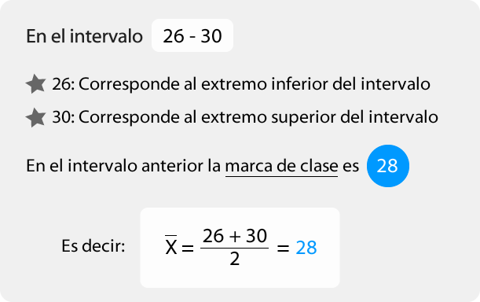

Marca de Clase

## Media de datos agrupados

Cuando los datos vienen agrupados en una tabla de frecuencias, la expresión de la media es distinta. Supongamos que tenemos $k$ clases diferentes en nuestra tabla de frecuencias, en donde para cada clase $C_i$, tenemos su marca de clase llamada $x_i$ y su frecuencia absoluta llamada $f_i$ correspondiente, entonces calculamos la media como:

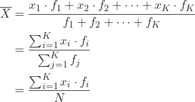

Media datos agrupados

Debemos notar que $N$, que es la cantidad de datos que poseemos en la muestra, no es más que la suma de frecuencias de cada clase, esto es,

$$N = \sum_{j=1}^k f_j$$

**Ejemplo**

Determinar la media de la siguiente tabla de frecuencia:

Dado que tenemos 5 clases o intervalos, utilizamos la fórmula anterior con $k = 5$, o sea:

$$\bar{x} = \frac{x_1 \cdot f_1 + x_2 \cdot f_2 + x_3 \cdot f_3 + x_4 \cdot f_4 + x_5 \cdot f_5 }{N} = \frac{\sum_{i=1}^{5} x_i \cdot f_i}{N}$$

Entonces procedemos en la tabla a realizar la multiplicación de cada marca de clase $x_i$ por la frecuencia respectiva $f_i$:

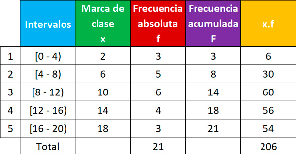

Finalmente calculamos el valor de la media, dividiendo la suma de valores de la columna $x_i \cdot f_i$ entre $N$.

$$\begin{align}
\bar{x} &= \frac{6 + 30 + 60 + 56 + 54}{21} \\
&= \frac{206}{21} \\
&= 9,810
\end{align}$$

El valor de la media sería $9,810$.

## Mediana

La **mediana** se encuentra en el intervalo donde la frecuencia acumulada llega hasta la mitad de la suma de las frecuencias absolutas. Por lo tanto, para estimar la mediana, hay que seguir dos pasos:

- Encontrar el intervalo en el que se encuentra la mediana usando la siguiente fórmula:

$$\textrm{posición} = \frac{N+1}{2}$$

- Usar la siguiente fórmula para hallar la mediana:

$$M_e = L_i + \frac{\frac{N}{2} - F_{i-1}}{f_i} \cdot A_i$$

Donde:

- $L_i$: es el límite inferior del intervalo en el cual se encuentra la mediana.
- $N$: es el número de datos del estudio. Es la sumatoria de las frecuencias absolutas.
- $F_{i-1}$: es la frecuencia acumulada del intervalo anterior al que se encuentra la mediana.
- $A_i$: es la amplitud del intervalo en el que se encuentra la mediana.
- $f_i$: es la frecuencia absoluta del intervalo en el que se encuentra la mediana.

**Ejemplo:**

Encontrar la mediana de la siguiente tabla de frecuencia:

Para estimar el valor de la mediana, seguimos los dos pasos anteriormente mencionados.

Primero encontramos el intervalo en el cual se encuentra la mediana usando la fórmula:

$$\textrm{posición} = \frac{N+1}{2} = \frac{21 + 1}{2} = \frac{22}{2} = 11$$

Este valor lo buscamos en la columna de **frecuencias acumuladas**. Si no aparece, buscamos el valor que sigue. Como vemos, después del $11$ sigue el $14$, por lo tanto, **la mediana se ubica en el intervalo** $3$.

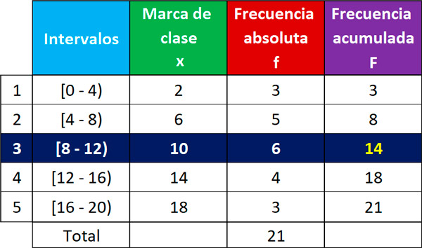

Ahora, aplicamos la fórmula de la mediana:

$$\begin{align}
M_e &= L_i + \frac{\frac{N}{2} - F_{i-1}}{f_i} \times A_i \\
&= 8 + \frac{\frac{21}{2} - 8}{6} \times 4 \\
&= 9,667
\end{align}$$

El valor de la mediana sería $9,667$.

## Moda

Para estima la moda, se siguen los siguientes pasos:

- Encontrar el intervalo en el cual se encuentra la moda, que es el intervalo con la mayor frecuencia absoluta.
- Usar la siguiente fórmula para estimar el valor de la moda:

$$M_o = L_i + \frac{f_i - f_{i-1}}{(f_i - f_{i-1}) + (f_i - f_{i+1})} \times A_i$$

Donde:

- $L_i$: es el límite inferior del intervalo en el cual se encuentra la moda.
- $f_{i-1}$: es la frecuencia absoluta del intervalo anterior en el que se encuentra la moda.
- $f_i$: es la frecuencia absoluta del intervalo en el que se encuentra la moda.
- $f_{i+1}$: es la frecuencia absoluta del intervalo siguiente en el que se encuentra la moda.
- $A_i$: es la amplitud del intervalo en el que se encuentra la moda.

**Ejemplo**

Encontrar la moda de la siguiente tabla de frecuencia:

Primero, encontramos el intervalo en el cual se encuentra la moda, es decir, el intervalo con mayor frecuencia absoluta. El intervalo $3$, tiene la mayor frecuencia absoluta ($6$), por lo tanto, aquí se encontrará la moda.

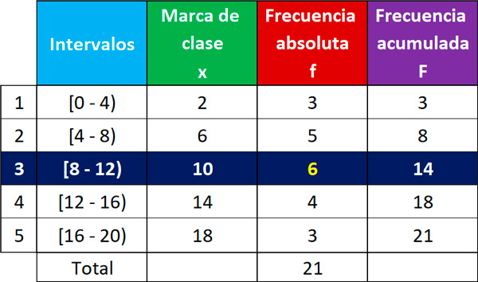

Ahora aplicamos la fórmula para encontrar la moda:

$$\begin{align}
M_o &= L_i + \frac{f_i - f_{i-1}}{(f_i - f_{i-1}) + (f_i - f_{i+1})} \times A_i \\
&= 8 + \frac{6 - 5}{(6-5) + (6-4)} \times 4 \\
&= 9,333
\end{align}$$

Por lo tanto, el valor de la moda sería: $M_o = 9,333$.